# Atividade 6

```
FALSE [1]  1 24
```

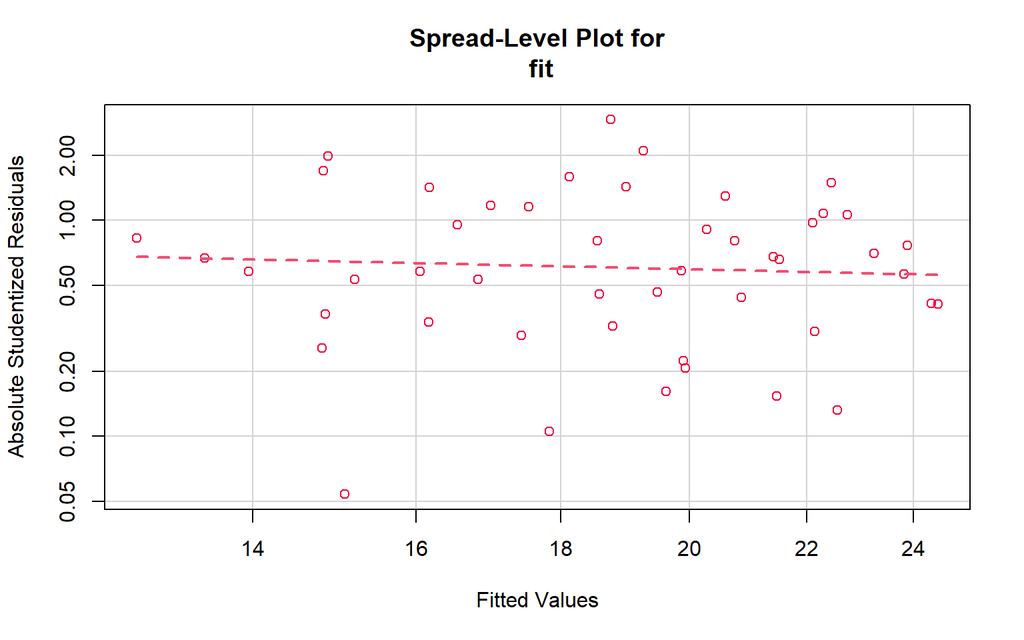

```
FALSE
FALSE Suggested power transformation:  1.291778
```

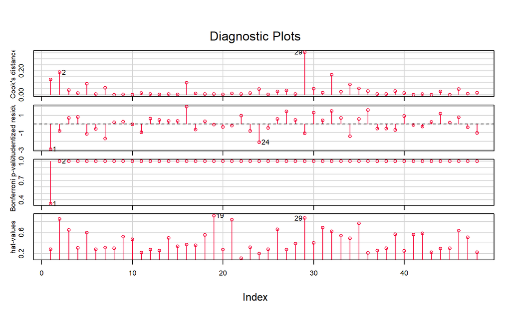

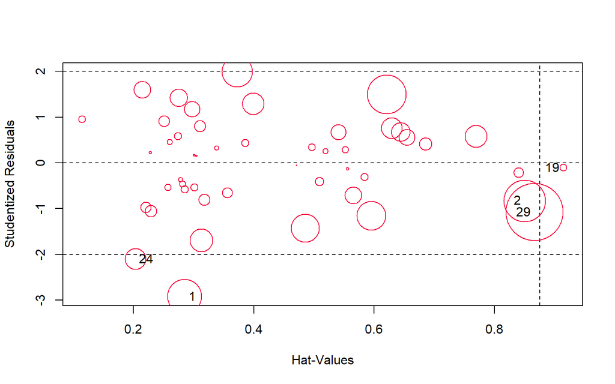

```
FALSE       StudRes       Hat       CookD
FALSE 1  -2.9229307 0.2852726 0.126921297
FALSE 2  -0.8293820 0.8501287 0.187977467
FALSE 19 -0.1053529 0.9143519 0.005856997
FALSE 24 -2.0993501 0.2030691 0.047485373
FALSE 29 -1.0778962 0.8664641 0.356854589
```

Com essa análise inicial, podemos dizer que o modelo não tem problemas com falta de ajuste, os resíduos também parecem se distribuir normalmente. Podemos notar a presença de pontos de alavancagem e outliers, e também um problema com alta multicoliunearidade, já que o valore do coeficiente de variação, e do coeficiente de variação ajustado parecem diferir bastante, além dos valores que econtramos no teste VIF serem muito maiores que 10, que é o valor tolerável. Além disso, apenas a covariável “mo” é significativa, com 5% de significância. Dito isso, vamos escolher três covariáveis, retirar as observações referentes às linhas 1, 2 e 29 e ajustar um novo modelo. Depois disso, vamos realizar novamente a devida análise diagnóstica.

```r
tb <- tb[-c(1,2,29),]
tb <- tb[,c(1,8,9,10)]
fit <- lm(alt~., data = tb)
pander(summary(fit))
```

|  | Estimate | Std. Error | t value | Pr(>\|t\|) |
| --- | --- | --- | --- | --- |
| **(Intercept)** | 9.498 | 1.832 | 5.183 | 6.21e-06 |
| **ctc** | 0.8438 | 0.1809 | 4.664 | 3.278e-05 |
| **sat** | 0.04375 | 0.03684 | 1.188 | 0.2418 |
| **mo** | -0.04979 | 0.0242 | -2.057 | 0.04606 |

Fitting linear model: alt ~ .

| Observations | Residual Std. Error | $R^2$ | Adjusted $R^2$ |
| --- | --- | --- | --- |
| 45 | 2.19 | 0.6506 | 0.625 |

```r
pander(vif(fit))
```

| ctc | sat | mo |
| --- | --- | --- |
| 3.778 | 2.59 | 2.108 |

Com essas mudanças, podemos perceber que os problemas com multicolinearidade foram resolvidos, porém ainda precisamos verificar outros pontos importantes, como falta de ajuste, desvio de normalidade, pontos de alavancagem, presença de outliers e homocedasticidade. Então, vamos fazer os tester a seguir:

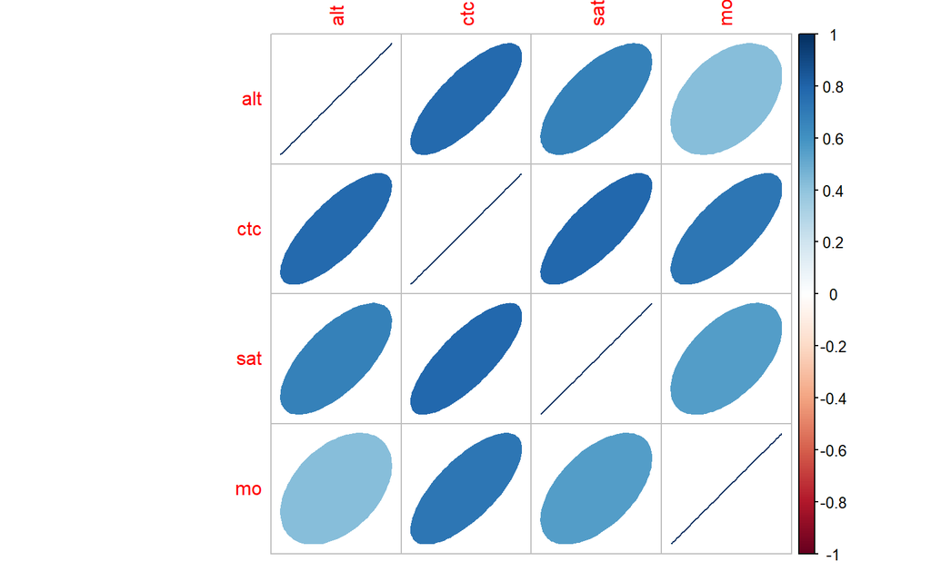

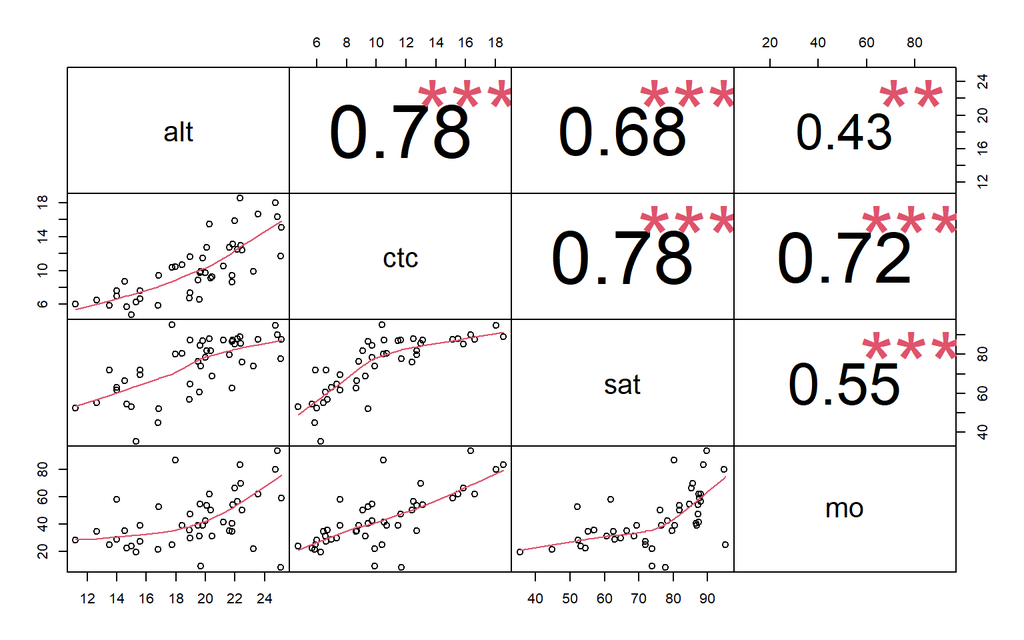

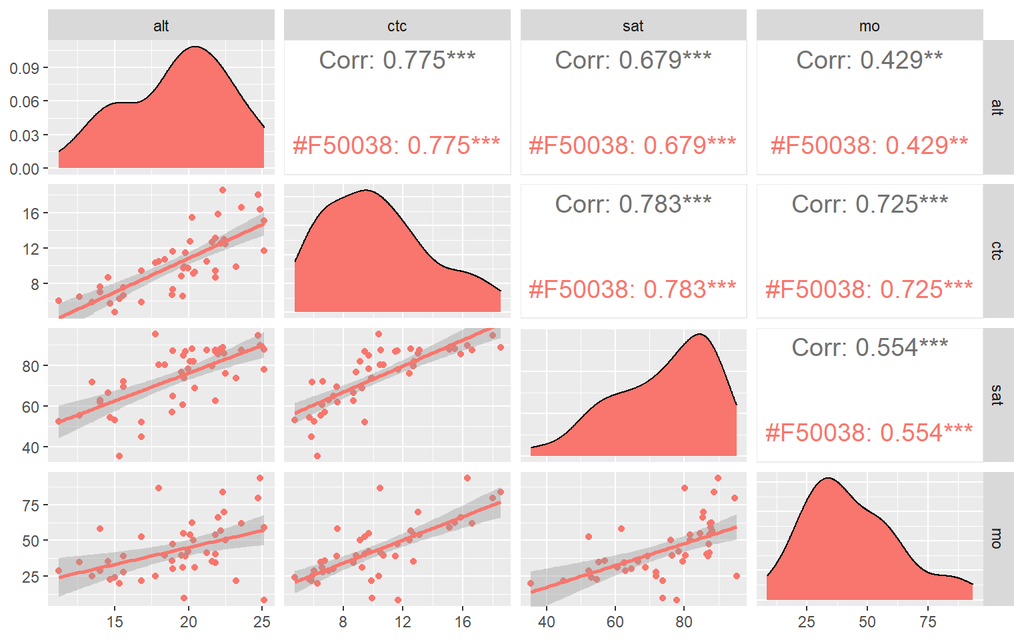

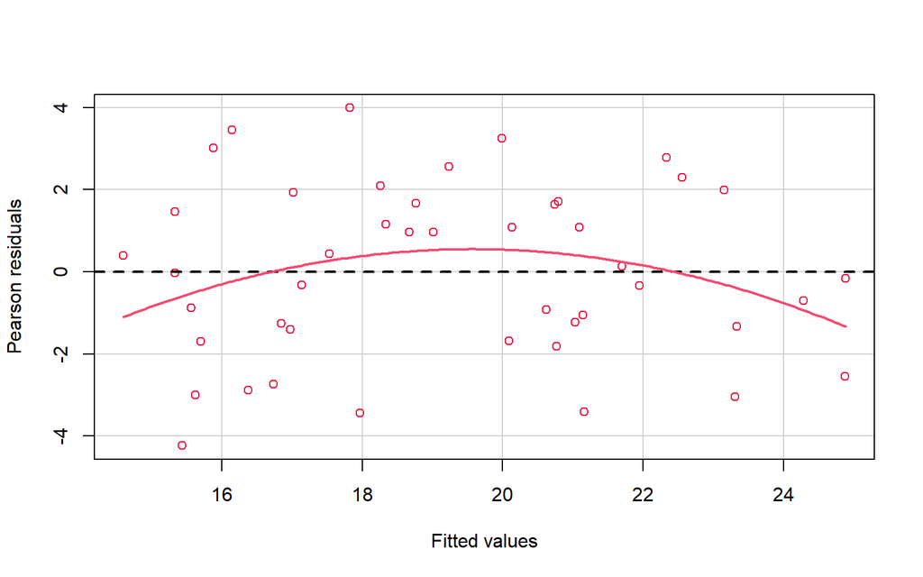

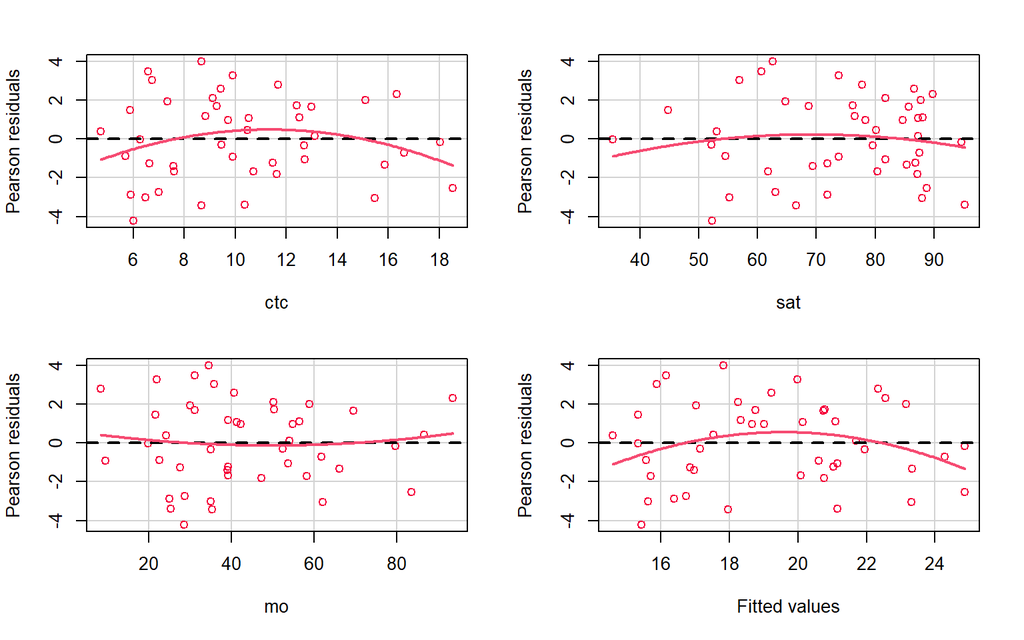

```
FALSE            Test stat Pr(>|Test stat|)
FALSE ctc          -1.7707          0.08423 .
FALSE sat          -0.7118          0.48074
FALSE mo            0.4861          0.62954
FALSE Tukey test   -2.1189          0.03410 *
FALSE ---
FALSE Signif. codes:  0 '***' 0.001 '**' 0.01 '*' 0.05 '.' 0.1 ' ' 1
```

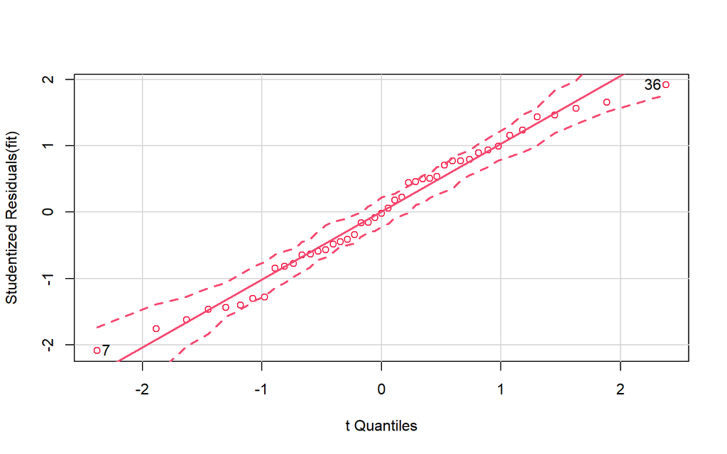

```
FALSE  7 36
FALSE  5 33
```

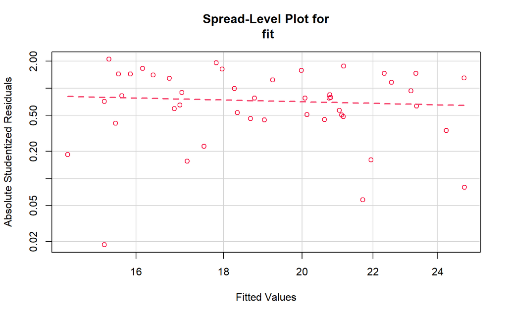

```
FALSE
FALSE Suggested power transformation:  1.420495
```

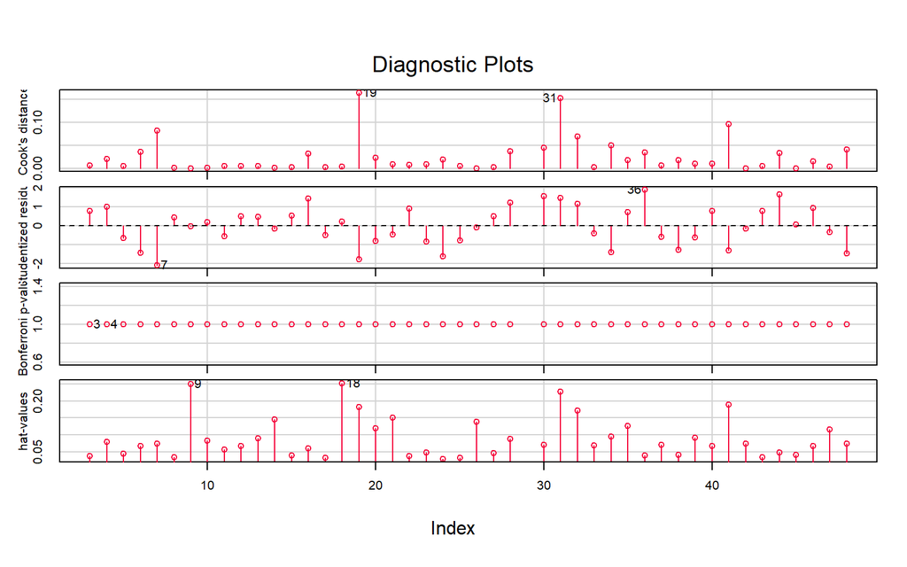

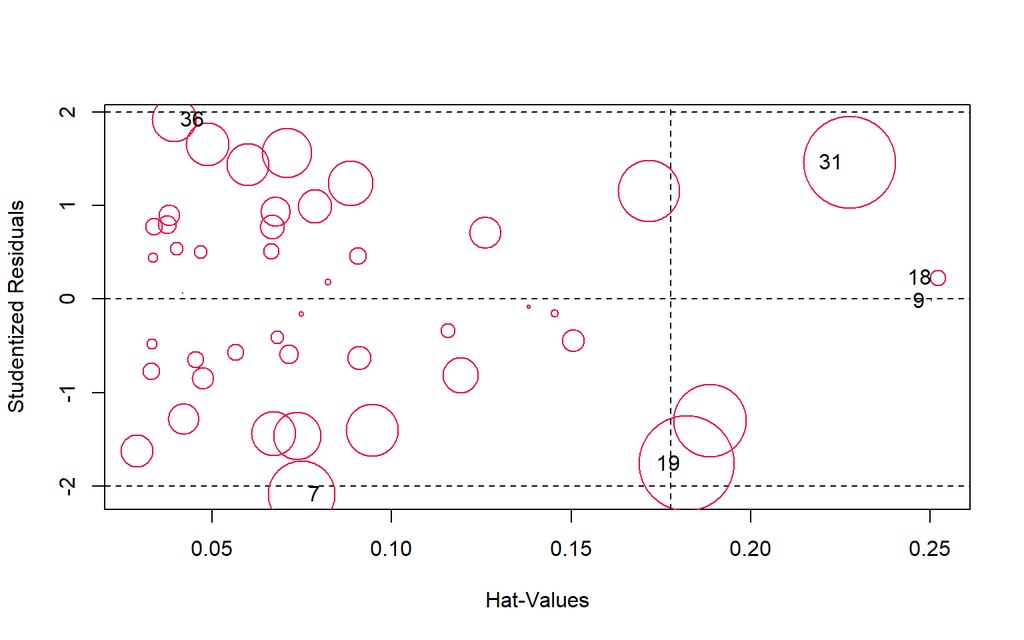

```
FALSE        StudRes        Hat        CookD
FALSE 7  -2.08839130 0.07484026 8.151943e-02
FALSE 9  -0.01837011 0.25030956 2.887215e-05
FALSE 18  0.22605282 0.25221579 4.410880e-03
FALSE 19 -1.76241705 0.18217656 1.645263e-01
FALSE 31  1.46220204 0.22748718 1.531495e-01
FALSE 36  1.91762017 0.03929327 3.529563e-02
```

O problema de multicolinearidade parece ter sido corrigido, e o nosso modelo explica bem a variação da variável dependente, se considerarmos como parâmetro o coeficientes de variação. Quase todos os parâmetros são significativos, a 5% de significância, porém parece ter algum problema de falta de ajuste, então, antes de fazermos qualquer outra análise, iremos tentar corrigir esse problema. Vamos fazer isso elevando as covariáveis “ctc”, “sat” e “mo” a 1/9, ou seja, utilizar a raíz nona dessas covariáveis, também, vamos elevar a variável resposta ao quadrado.

```r
tb$ctc <- (tb$ctc)^(1/9)
tb$mo <- (tb$mo)^(1/9)
tb$sat <- (tb$sat)^(1/9)
tb$alt <- (tb$alt)^(2)
```

|  | Estimate | Std. Error | t value | Pr(>\|t\|) |
| --- | --- | --- | --- | --- |
| **(Intercept)** | -2488 | 510.9 | -4.87 | 1.705e-05 |
| **ctc** | 2486 | 427.1 | 5.82 | 7.793e-07 |
| **sat** | 171.4 | 501.3 | 0.3419 | 0.7342 |
| **mo** | -403.6 | 176.5 | -2.287 | 0.02744 |

Fitting linear model: alt ~ .

| Observations | Residual Std. Error | $R^2$ | Adjusted $R^2$ |
| --- | --- | --- | --- |
| 45 | 77.99 | 0.6855 | 0.6625 |

| ctc | sat | mo |
| --- | --- | --- |
| 3.226 | 2.698 | 1.573 |

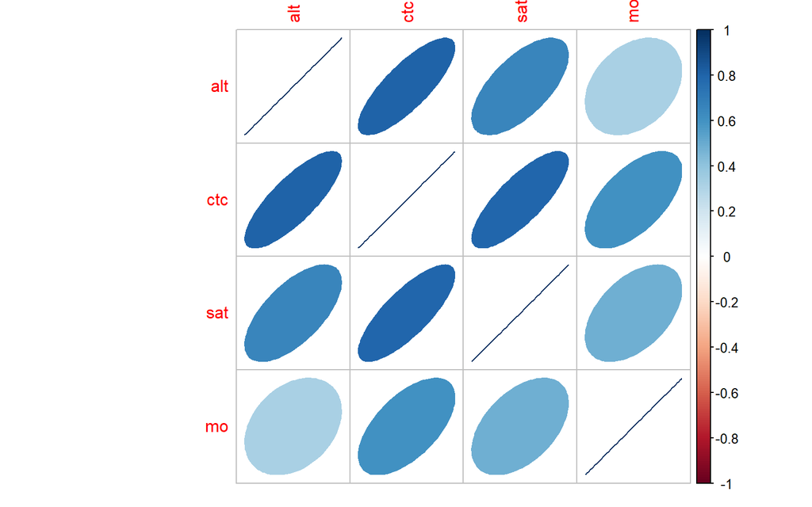

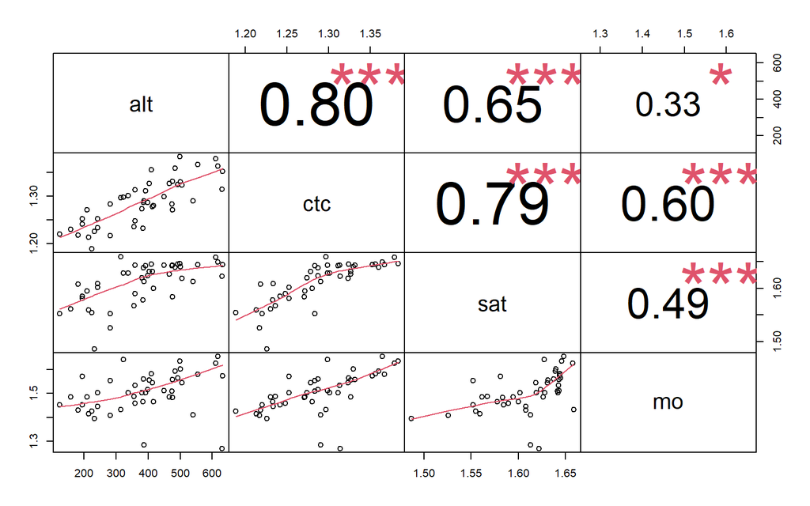

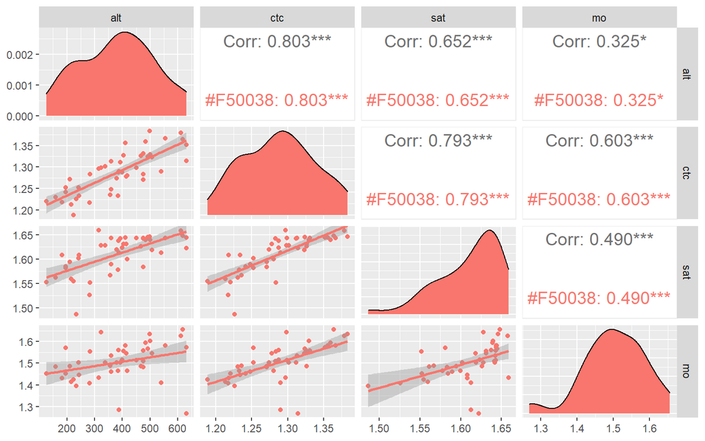

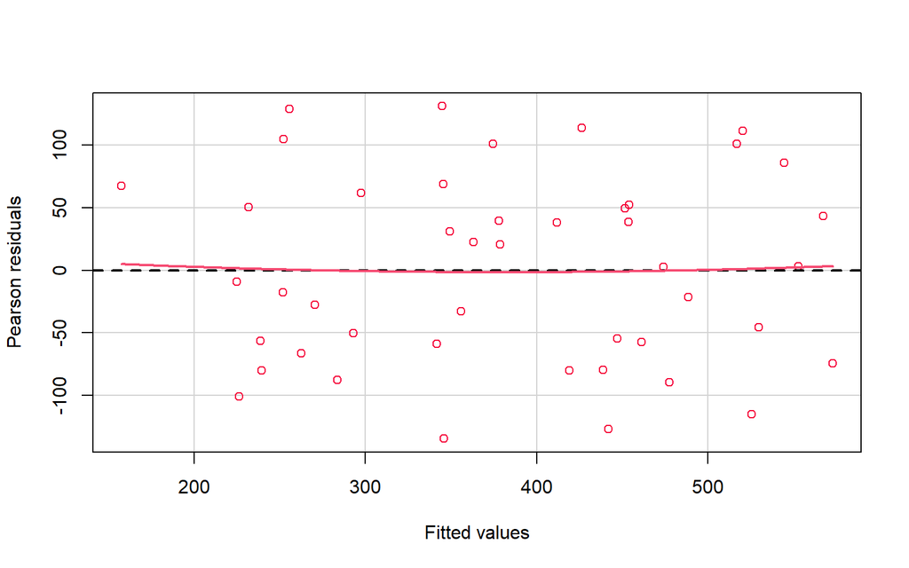

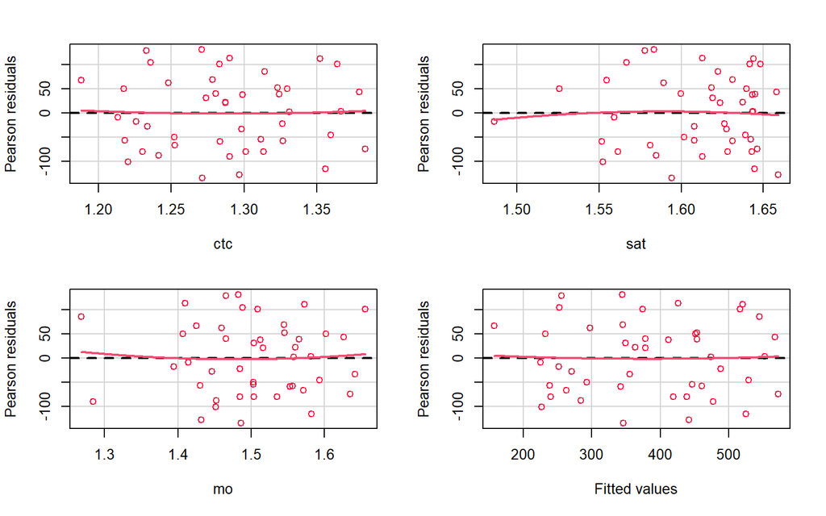

```
FALSE            Test stat Pr(>|Test stat|)
FALSE ctc           0.1540           0.8784
FALSE sat          -0.2913           0.7723
FALSE mo            0.3813           0.7050
FALSE Tukey test    0.1350           0.8926
```

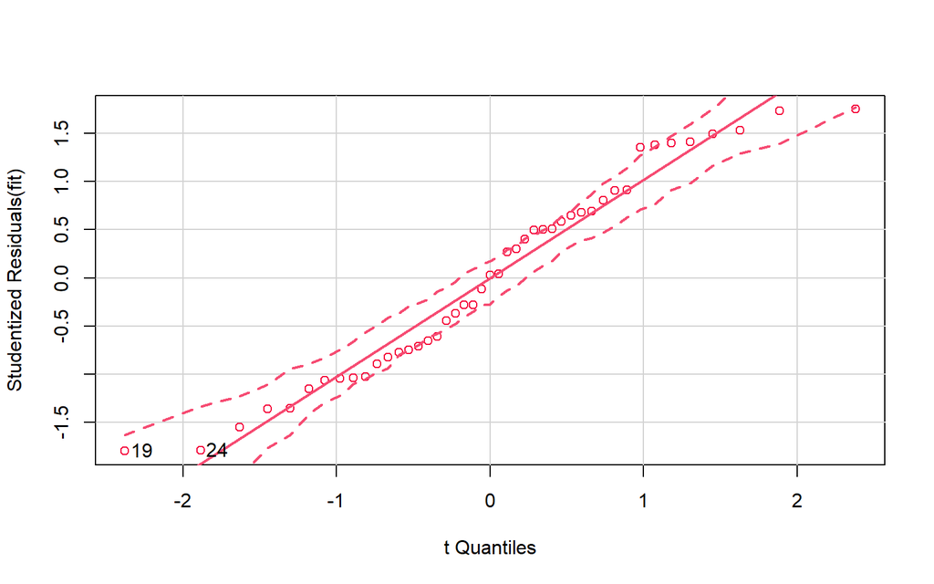

```
FALSE 19 24
FALSE 17 22
```

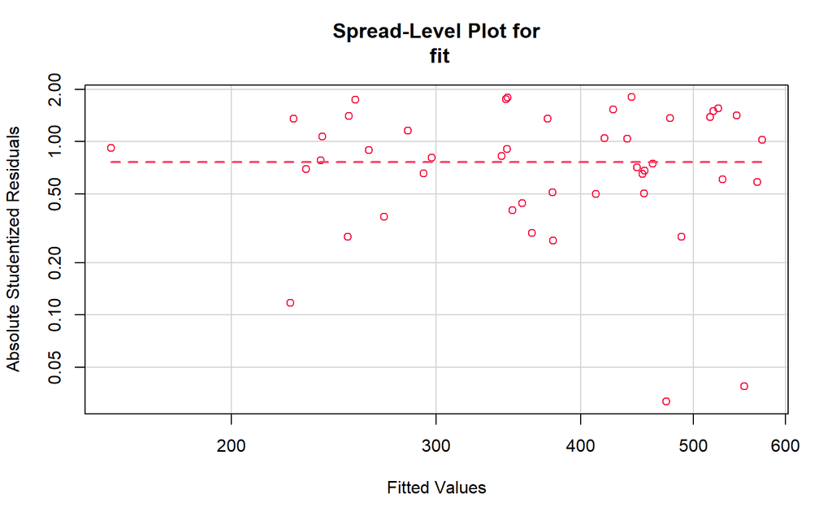

```
FALSE
FALSE Suggested power transformation:  1.001133
```

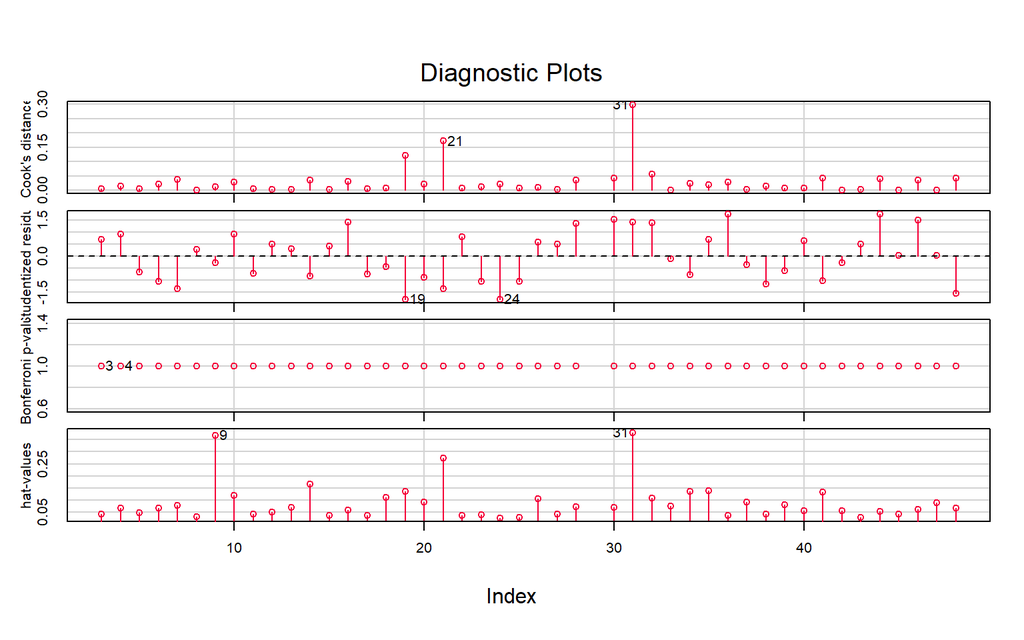

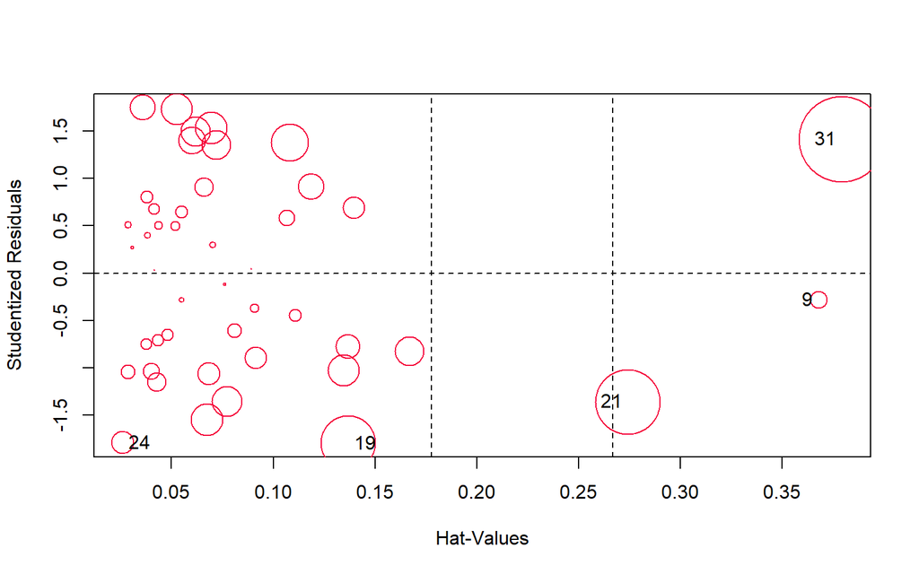

```
FALSE       StudRes        Hat      CookD
FALSE 9  -0.2821445 0.36787350 0.01184781
FALSE 19 -1.7997393 0.13700371 0.12189622
FALSE 21 -1.3602991 0.27423646 0.17124700
FALSE 24 -1.7931307 0.02607035 0.02041406
FALSE 31  1.4152421 0.37928685 0.29866396
```

|  | Estimate | Std. Error | t value | Pr(>\|t\|) |
| --- | --- | --- | --- | --- |
| **(Intercept)** | -2735 | 535.2 | -5.11 | 1.003e-05 |
| **ctc** | 2708 | 433.2 | 6.251 | 2.876e-07 |
| **sat** | 273.5 | 506.5 | 0.5399 | 0.5925 |
| **mo** | -541.1 | 200 | -2.706 | 0.01024 |

Fitting linear model: alt ~ .

| Observations | Residual Std. Error | $R^2$ | Adjusted $R^2$ |
| --- | --- | --- | --- |
| 41 | 75.85 | 0.7277 | 0.7056 |

| ctc | sat | mo |
| --- | --- | --- |
| 3.171 | 2.507 | 1.685 |

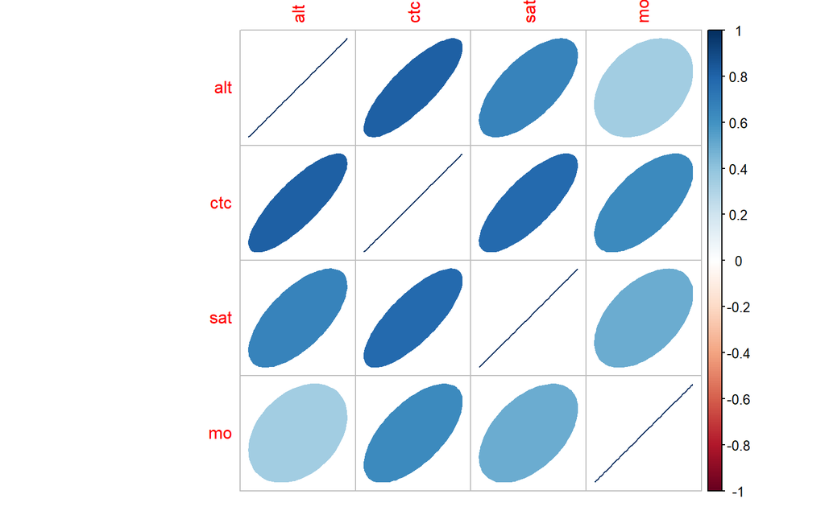

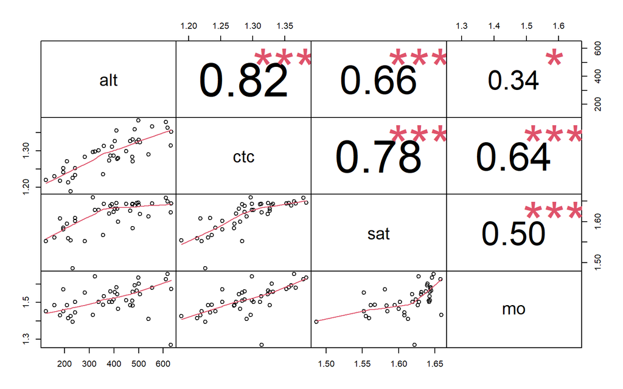

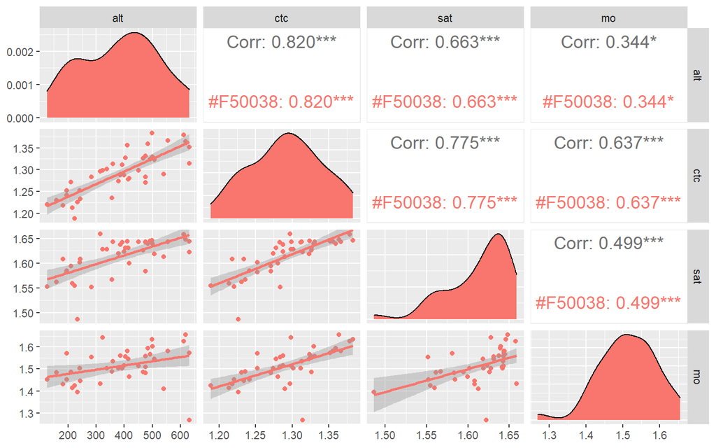

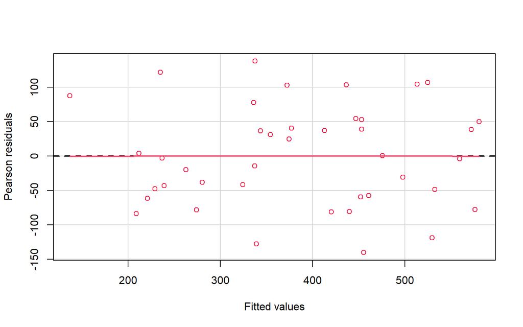

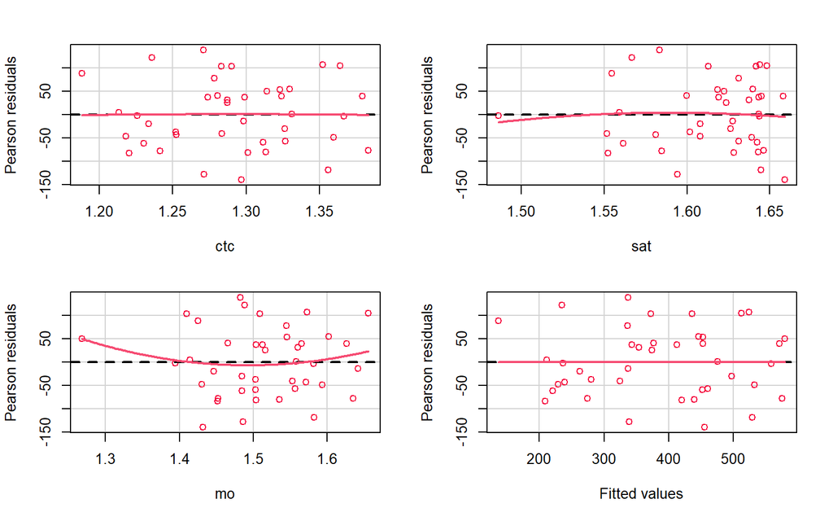

```
FALSE            Test stat Pr(>|Test stat|)
FALSE ctc          -0.0437           0.9654
FALSE sat          -0.3342           0.7401
FALSE mo            1.0576           0.2973
FALSE Tukey test   -0.0112           0.9910
```

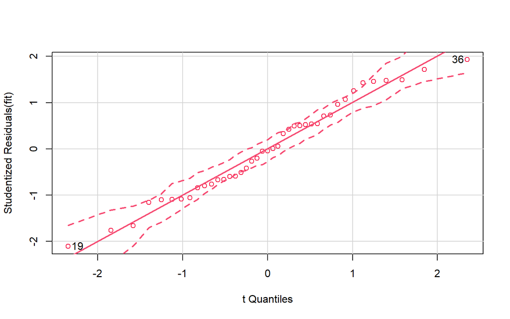

```
FALSE 19 36
FALSE 17 30
```

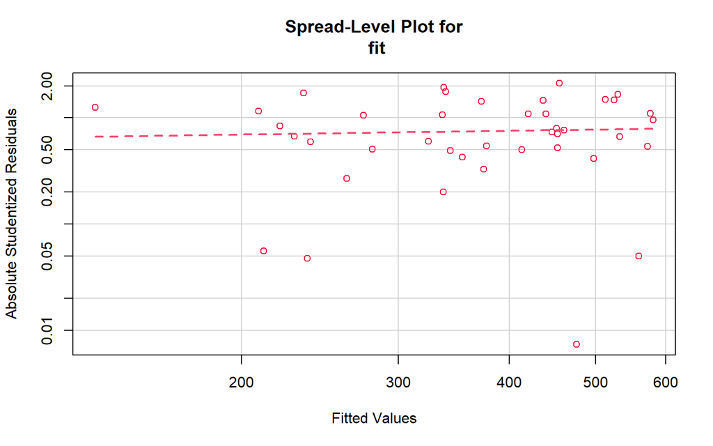

```
FALSE
FALSE Suggested power transformation:  0.8796586
```

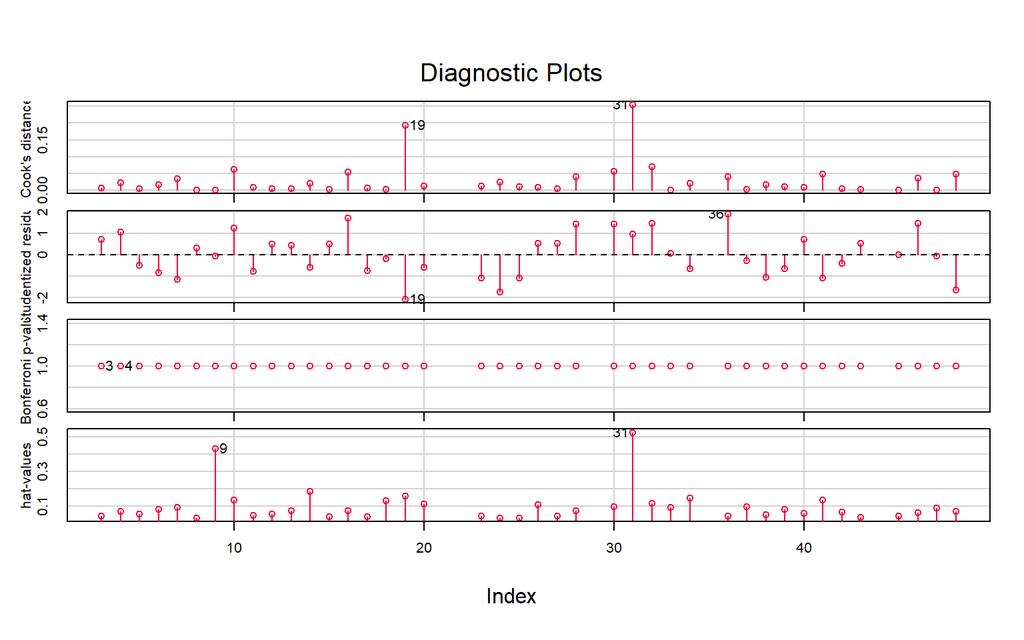

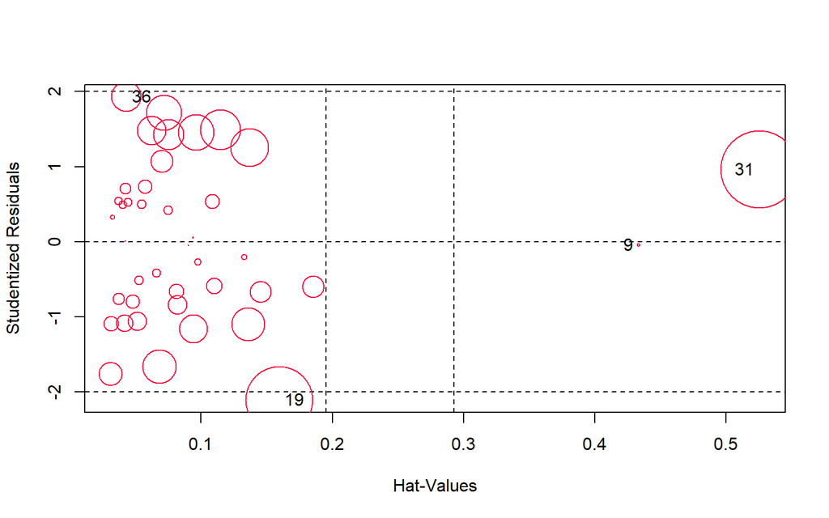

```
FALSE        StudRes        Hat        CookD
FALSE 9  -0.04775061 0.43310349 0.0004475663
FALSE 19 -2.10751035 0.15960242 0.1929334400
FALSE 31  0.95927530 0.52531273 0.2551375950
FALSE 36  1.92841469 0.04326737 0.0391666618
```

Esse novo modelo apresenta um coeficiente de determinação alto, baixa multicolinearidade, não aparenta problemas de homocedasticidade e de falta de ajuste, os erros parecem se adequar bem a distribuição normal e os possíveis pontos de alavancagem que encontramos são importantes para explicar a variação da variável dependente. Por isso, esse vai ser o modelo final escolhido, visto que o professor pediu um modelo que levasse em conta pelo menos três covariáveis. Caso contrário, o modelo final não seria esse, já que a covariável “sat” não se mostrou significativa, com 5% de significância, e seria removida do ajuste final. Apenas para fins ilustrativos, vou deixar abaixo esse modelo.

|  | Estimate | Std. Error | t value | Pr(>\|t\|) |
| --- | --- | --- | --- | --- |
| **(Intercept)** | -2502 | 314.4 | -7.958 | 1.294e-09 |
| **ctc** | 2868 | 312.8 | 9.169 | 3.595e-11 |
| **mo** | -540 | 198.1 | -2.726 | 0.00964 |

Fitting linear model: alt ~ .

| Observations | Residual Std. Error | $R^2$ | Adjusted $R^2$ |
| --- | --- | --- | --- |
| 41 | 75.14 | 0.7255 | 0.7111 |

| ctc | mo |
| --- | --- |
| 1.684 | 1.684 |